# A look at bioRxiv preprints

Tim Stuart

2 March 2016

After posting a my first [preprint](http://biorxiv.org/content/early/2016/02/21/039511) to biorxiv a few weeks ago, I have been periodically checking the number of views and PDF downloads. I became interested to see how many downloads or views the preprints on biorxiv typically get, but this type of information isn’t actually available. Altmetric must track this data, as it will tell you how a particular preprint ranks in relation to others, but that data hasn’t been made publicly available (as far as I can tell).

Not to worry, a little [python script](https://github.com/timoast/biorxivData/blob/master/scrape_biorxiv.py) I wrote will scrape this information from the biorxiv website and record it in a file.

Let’s take a look at the data.

```r
library(dplyr)
library(ggplot2)
library(readr)
library(lubridate)

data <- read_tsv("./data/biorxiv_data_2016_2_29.tsv")
collection_date <- ymd("2016_2_29")

str(data)
```

```
## Classes 'tbl_df', 'tbl' and 'data.frame':    3095 obs. of  6 variables:
##  $ Title              : chr  "Copy number variants in the sheep genome detected using multiple approaches" "Productive infection of field strains of avian coronavirus infectious bronchitis virus in chicken peripheral blood-derived mono"| __truncated__ "Recurrent selection explains genomic regions…
##  $ URL                : chr  "http://biorxiv.org/content/early/2016/02/26/041475" "http://biorxiv.org/content/early/2016/02/26/041558" "http://biorxiv.org/content/early/2016/02/26/041467" "http://biorxiv.org/content/early/2016/02/26/041368" ...
##  $ Abstract views     : int  131 NA 321 70 161 570 714 276 428 318 ...
##  $ PDF views          : int  10 NA 14 3 8 102 106 45 65 42 ...
##  $ Original submission: Date, format: "2016-02-26" "2016-02-26" ...
##  $ Current submission : Date, format: "2016-02-26" "2016-02-26" ...
```

As you can see, the python script gathers data on the title, url, number of abstract views, number of PDF downloads, original upload date, and the date that the current version was uploaded (this will be the same as the original upload date in many cases).

Let’s add the age of the preprint and whether it was revised (true/false).

```r
data <-  data %>%
  mutate(Age = collection_date - ymd(`Original submission`),
         Revised = `Original submission` != `Current submission`)

str(data)
```

```
## Classes 'tbl_df', 'tbl' and 'data.frame':    3095 obs. of  8 variables:
##  $ Title              : chr  "Copy number variants in the sheep genome detected using multiple approaches" "Productive infection of field strains of avian coronavirus infectious bronchitis virus in chicken peripheral blood-derived mono"| __truncated__ "Recurrent selection explains genomic regions…
##  $ URL                : chr  "http://biorxiv.org/content/early/2016/02/26/041475" "http://biorxiv.org/content/early/2016/02/26/041558" "http://biorxiv.org/content/early/2016/02/26/041467" "http://biorxiv.org/content/early/2016/02/26/041368" ...
##  $ Abstract views     : int  131 NA 321 70 161 570 714 276 428 318 ...
##  $ PDF views          : int  10 NA 14 3 8 102 106 45 65 42 ...
##  $ Original submission: Date, format: "2016-02-26" "2016-02-26" ...
##  $ Current submission : Date, format: "2016-02-26" "2016-02-26" ...
##  $ Age                :Class 'difftime'  atomic [1:3095] 3 3 3 3 3 3 3 3 26 4 ...
##   .. ..- attr(*, "units")= chr "days"
##  $ Revised            : logi  FALSE FALSE FALSE FALSE FALSE FALSE ...
```

### bioRxiv metrics

How many preprints are revised at some stage?

```r
data %>%
  group_by(Revised) %>%
  summarise(n = n(), `%` = n/nrow(data) * 100)
```

```
## Source: local data frame [2 x 3]
##
##   Revised     n        %
##     (lgl) (int)    (dbl)
## 1   FALSE  2220 71.72859
## 2    TRUE   875 28.27141
```

So only 28% are ever revised.

What’s the average number of abstract views and PDF downloads for preprints?

```r
abstr_mn <- mean(data$`Abstract views`, na.rm = T)
abstr_med <- median(data$`Abstract views`, na.rm = T)
pdf_mn <- mean(data$`PDF views`, na.rm = T)
pdf_med <- median(data$`PDF views`, na.rm = T)
```

The mean number of abstract views was 485, and the median was 297. For PDF views, it was 134 and 64.

The mean seems to be pulled up by some outliers with very high numbers of views.

### Top 10 bioRxiv preprints

```r
top10 <- data %>%
  arrange(-`PDF views`) %>%
  select(Title, `Abstract views`, `PDF views`, Age, Revised) %>%
  head(., 10)
knitr::kable(top10)  # output as nicely formatted table
```

| Title | Abstract views | PDF views | Age | Revised |
| --- | --- | --- | --- | --- |
| Massive migration from the steppe is a source for Indo-European languages in Europe | 17385 | 15170 | 384 days | FALSE |
| Revised estimates for the number of human and bacteria cells in the body | 23174 | 9625 | 54 days | FALSE |
| Accelerating Scientific Publication in Biology | 12206 | 5504 | 233 days | TRUE |
| The genome of the tardigrade Hypsibius dujardini | 22074 | 4084 | 90 days | TRUE |
| Real time selective sequencing using nanopore technology. | 6906 | 4039 | 26 days | FALSE |
| Simple multi-trait analysis identifies novel loci associated with growth and obesity measures | 4362 | 2905 | 236 days | FALSE |
| A vision for ubiquitous sequencing | 2435 | 2735 | 298 days | TRUE |
| ￼TP53 copy number expansion correlates with the evolution of increased body size and an enhanced DNA damage response in elephants | 12275 | 2502 | 146 days | TRUE |
| Reconstructing Genetic History of Siberian and Northeastern European Populations | 2079 | 2410 | 134 days | TRUE |
| Genome variation and meiotic recombination in Plasmodium falciparum: insights from deep sequencing of genetic crosses | 559 | 2408 | 206 days | TRUE |

### Distribution of views

Let’s first filter out preprints less than 10 days old, as these probably have an artificially low number of views.

```r
older_than_10 <- filter(data, Age > 10)
quantile(older_than_10$`PDF views`, na.rm =TRUE)
```

```
##    0%   25%   50%   75%  100%
##     0    33    65   127 15170
```

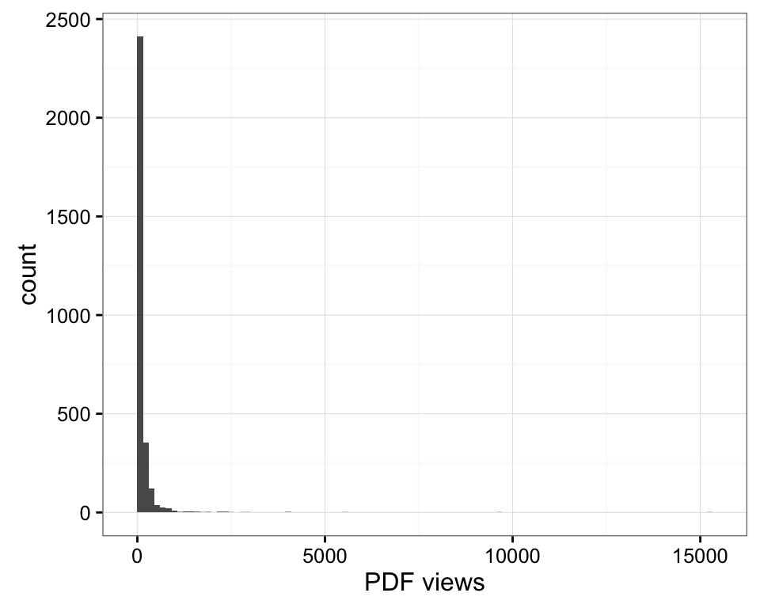

```r
ggplot(older_than_10, aes(`PDF views`)) +
  geom_histogram(bins = 100) + theme_bw()
```

This would be better looked at on a log scale:

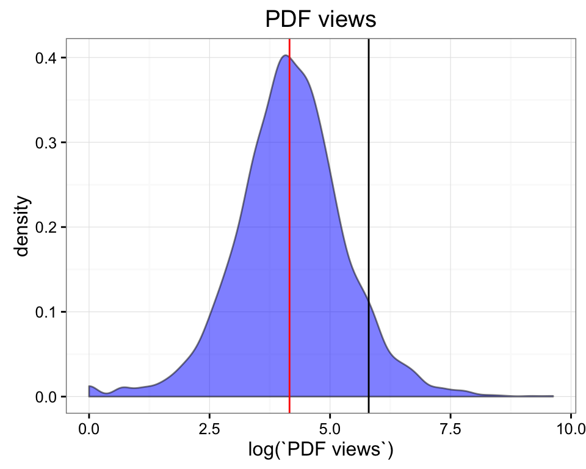

```r
ggplot(older_than_10, aes(log(`PDF views`))) +
  ggtitle("PDF views") +
  geom_density(fill = 'blue', alpha = 0.5) + theme_bw() +
  geom_vline(xintercept = log(pdf_med), col = 'red') +
  geom_vline(xintercept = log(331))  # my paper
```

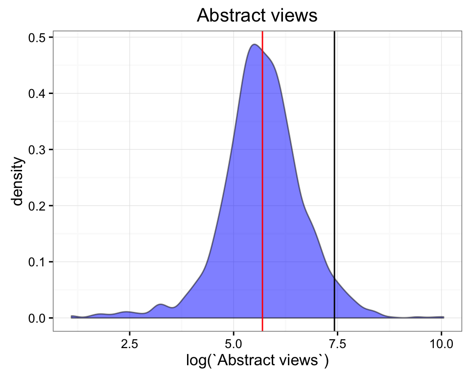

```r
ggplot(older_than_10, aes(log(`Abstract views`))) +
  ggtitle("Abstract views") +
  geom_density(fill = 'blue', alpha = 0.5) + theme_bw() +
  geom_vline(xintercept = log(abstr_med), col = 'red') +
  geom_vline(xintercept = log(1678))  # my paper
```

There’s plenty more I could look at, but for now this satifies my basic curiosity. I’ve posted the data and code on [GitHub](https://github.com/timoast/biorxivData), so interested people can download and play with it themselves.